# Question 1

`Explain the differences between RDD and a traditional Relational Database System.`

- RDD (Resilient Distributed Dataset) represents an immutable, partitioned collection of elements that can be operated on in parallel.Immutable elements means that once you create an RDD you can't change it. RDDs are fault tolerant, hence in case of failure, they recover automatically.
- Relational Database System stores and provides access to data points that are related to one another. It's a straightforward way of representing data tables. Structured Query Language (SQL) is almost used for this type of databases. It very important to state that each row in the table is a record with a unique ID (Key), columns (attributes). *Each record usually has a value for each attribute.

Some Differences between these two:

- Structure and Storage: We know RDD represents an immutable partitioned collected of elements (unstructured data) which are stored in memory or on disks of different machines of a cluster. In contrast, RDB stores structured data in table format with rows and columns. It (RDB) organizes data into relatable tables as stated above and stores information within disks.
- API/Languages: RDD has API for the following languages (Python, R, Scala, and Java) which help us perform many important operations for data manipulation. In the other hand, Relational Databases use SQL to manipulate the and query data.
- Performance/Reading Files: As we know, RDBs are more used for data retrieval tasks and reporting (analytics). Since Spark has API for different programming languages, we can even use RDDs for other tasks like data processing and machine learning. We can do more data science related tasks using RDDS than using RDBs. It is also easier to read CSV, Text, and XML Files in RDDs.
- Fault Tolerance: RDDs are fault tolerance by nature, meaning that if something goes wrong it can recover automatically. In order to make a Relational Database Fault Tolerance, we can use the "ACID" guidelines to ensure good transactions. "ACID" stands for Atomocity, Consistency, Isolation, Durability. This will help with data integrity if something wrong happens. Professor Scrivner talked about this.

# Question 2

`WordCount Application`

## Question 2: Setting up PySpark Environment in Colab

```python
!pip install pyspark py4j
```

## Question 2 Installing NLTK

- This was very useful for the Introduction to Natural Language Processing class with professor Olga Scrivner.

```python
!pip install nltk
```

```python
import nltk
nltk.download('stopwords')
```

```python
from nltk.corpus import stopwords
print(stopwords.words('english'))
```

```
['i', 'me', 'my', 'myself', 'we', 'our', 'ours', 'ourselves', 'you', "you're", "you've", "you'll", "you'd", 'your', 'yours', 'yourself', 'yourselves', 'he', 'him', 'his', 'himself', 'she', "she's", 'her', 'hers', 'herself', 'it', "it's", 'its', 'itself', 'they', 'them', 'their', 'theirs', 'themselve…
```

## Question 2 WordCount Application

The idea behind this WordCount application came from the source: learntospark.com in references.

```python
from pyspark.sql import SparkSession
from pyspark.conf import SparkConf
```

```python
spark = SparkSession.builder\
        .master('local[*]')\
        .appName('WordCount')\
        .getOrCreate()
```

```python
sc = spark.sparkContext
```

```python
txt = sc.textFile('eBook_datafile.txt')
```

```python
stop_words = set(stopwords.words('english'))

# Pronoun list from github, decided to add some relatuve pronouns.
p = {'I','you','my','mine','myself','we','us','our','ours','ourselves',
      'your','yours','yourself','he','him','his','himself','she','her',
      'herself','it','its','itself','they','them','their','theirs','themself',
      'what', 'which', 'who', 'whom', 'this', 'that', 'these', 'those'}
```

```python
# Combine stopwords and pronouns
#def union(lst1, lst2):
  #final_list = lst1 + lst2
  #return final_list

# this can be useful however we want a list with no duplicate
#filtered_words = union(p,stop_words)

# Duplicates are exlcuded
filtered_words = stop_words.union(p)
```

```python
wrd_count = txt.flatMap(lambda line: line.split(' ')) \
             .filter(lambda word: word.lower() not in filtered_words) \
             .map(lambda word: (word, 1)) \
             .reduceByKey(lambda x, y: x + y)
```

```python
output = wrd_count.collect()

for (word, count) in output:
    print(f'{word}, {count}')
```

```
Project, 78
Anthem,, 1
Ayn, 3
Rand, 3
, 10915
use, 11
anyone, 4
anywhere, 2
United, 15
States, 7
world, 9
restrictions, 2
whatsoever., 3
may, 29
it,, 31
give, 17
away, 15
re-use, 2
online, 4
check, 4
country, 4
using, 6
eBook., 2
Anthem, 1
Author:, 1
Date:, 1
[eBook, 1
#1250], 1
January, 1
21,, 1
2021], 1
Language:, 1
English, 1
Character, 1
set, 10
UTF-8, 1
anonymous, 1
group, 2
***, 4
GUTENBERG, 3
```

[output cut: 3743 more lines]

```
credit, 1
visit:, 1
S., 1
originator, 1
support., 1
editions,, 1
included., 1
necessarily, 1
edition., 1
main, 1
PG, 1
includes, 1
Gutenberg-tm,, 1
email, 1
newsletter, 1
```

# Question 3

`Reductions in Spark`

```python
from pyspark.sql.functions import col, isnan
```

```python
df1 = spark.read.option('header', 'true').csv('Forecast_Data_Set.csv')
```

```python
df1.printSchema()
```

```
root
 |-- station: string (nullable = true)
 |-- Date: string (nullable = true)
 |-- Present_Tmax: string (nullable = true)
 |-- Present_Tmin: string (nullable = true)
 |-- LDAPS_RHmin: string (nullable = true)
 |-- LDAPS_RHmax: string (nullable = true)
 |-- LDAPS_Tmax_lapse: string (nullable = true)
 |-- LDAPS_Tmin_lapse: string (nullable = true)
 |-- LDAPS_WS: string (nullable = true)
 |-- LDAPS_LH: string (nullable = true)
 |-- LDAPS_CC1: string (nullable = true)
 |-- LDAPS_CC2: string (nullable = true)
 |-- LDAPS_CC3: string (nullable = true)
 |-- LDAPS_CC4: string (nullable = true)
 |-- LDAPS_PPT1: string (nullable = true)
 |-- LDAPS_PPT2: string (nullable = true)
 |-- LDAPS_PPT3: string (nullable = true)
 |-- LDAPS_PPT4: string (nullable = true)
 |-- lat: string (nullable = true)
 |-- lon: string (nullable = true)
 |-- DEM: string (nullable = true)
 |-- Slope: string (nullable = true)
 |-- Solar radiation: string (nullable = true)
 |-- Next_Tmax: string (nullable = true)
 |-- Next_Tmin: string (nullable = true)
```

```python
#df1.show()
df1.show(n=5, truncate=False)
```

```
+-------+----------+------------+------------+-----------+-----------+----------------+----------------+-----------+-----------+-----------+-----------+-----------+-----------+----------+----------+----------+----------+-------+-------+-------+------+---------------+---------+---------+
|station|Date      |Present_Tmax|Present_Tmin|LDAPS_RHmin|LDAPS_RHmax|LDAPS_Tmax_lapse|LDAPS_Tmin_lapse|LDAPS_WS   |LDAPS_LH   |LDAPS_CC1  |LDAPS_CC2  |LDAPS_CC3  |LDAPS_CC4  |LDAPS_PPT1|LDAPS_PPT2|LDAPS_PPT3|LDAPS_PPT4|lat    |lon    |DEM    |Slope |Solar radiation|Next_Tmax|Next_Tmin|
+-------+----------+------------+------------+-----------+-----------+----------------+----------------+-----------+-----------+-----------+-----------+-----------+-----------+----------+----------+----------+----------+-------+-------+-------+------+---------------+---------+---------+
|1      |2013-06-30|28.7        |21.4        |58.25568771|91.11636353|28.07410146     |23.00693617     |6.818886966|69.45180527|0.233947471|0.20389571 |0.161696854|0.130928198|0         |0         |0         |0         |37.6046|126.991|212.335|2.785 |5992.895996    |29.1     |21.2     |
|2      |2013-06-30|31.9        |21.6        |52.26339722|90.60472107|29.85068856     |24.03500932     |5.691889932|51.93744783|0.225508198|0.251771373|0.159444059|0.127727264|0         |0         |0         |0         |37.6046|127.032|44.7624|0.5141|5869.3125      |30.5     |22.5     |
|3      |2013-06-30|31.6        |23.3        |48.69047928|83.97358704|30.09129171     |24.56563342     |6.138223678|20.57304966|0.209343664|0.257469446|0.204091465|0.14212525 |0         |0         |0         |0         |37.5776|127.058|33.3068|0.2661|5863.555664    |31.1     |23.9     |
|4      |2013-06-30|32          |23.4        |58.23978806|96.48368835|29.7046289      |23.32617729     |5.650050263|65.72714393|0.216372027|0.226002422|0.16115741 |0.134248676|0         |0         |0         |0         |37.645 |127.022|45.716 |2.5348|5856.964844    |31.7     |24.3     |
|5      |2013-06-30|31.4        |21.9        |56.17409515|90.15512848|29.11393432     |23.48647993     |5.735004306|107.9655353|0.151406899|0.249995278|0.178892475|0.170020995|0         |0         |0         |0         |37.5507|127.135|35.038 |0.5055|5859.552246    |31.2     |22.5     |
+-------+----------+------------+------------+-----------+-----------+----------------+----------------+-----------+-----------+-----------+-----------+-----------+-----------+----------+----------+----------+----------+-------+-------+-------+------+---------------+---------+---------+
only showing top 5 rows
```

Since we are trying to "find the avg Present_Tmin" for each station, we would need to change the null values into some other data type. Maybe float to make it easier instead of changing it to integer.

Lets see the count of non null values.

```python
from pyspark.sql.functions import col, count

df1.filter(col('Present_Tmin').isNotNull()).groupBy('station').agg(count('Present_Tmin')).show()
```

```
+-------+-------------------+
|station|count(Present_Tmin)|
+-------+-------------------+
|      7|                310|
|     15|                310|
|     11|                310|
|      3|                310|
|      8|                310|
|     22|                310|
|     16|                310|
|   null|                  2|
|      5|                310|
|     18|                310|
|     17|                310|
|      6|                310|
|     19|                310|
|     23|                310|
|     25|                310|
|      9|                310|
|     24|                310|
|      1|                310|
|     20|                310|
|     10|                310|
+-------+-------------------+
only showing top 20 rows
```

```python
df1.describe('Present_Tmin').show()
```

```
+-------+------------+
|summary|Present_Tmin|
+-------+------------+
|  count|        7752|
|   mean|         NaN|
| stddev|         NaN|
|    min|        11.3|
|    max|         NaN|
+-------+------------+
```

```python
new_df1 = df1.withColumn('Present_Tmin', col('Present_Tmin').cast('float'))
```

```python
new_df1 = new_df1.filter(~isnan(new_df1['Present_Tmin'])) # ~ negates result

#new_df1 = new_df1.filter(~isnan(new_df1['Present_Tmin']))
#new_df1 = new_df1.filter(isNull('Present_Tmin'))
#new_df1 = new_df1.filter(col('Present_Tmin').isNull())
```

We have to transform from DataFrame into RDD so we can use the transformation operations.

```python
RDD = new_df1.rdd
```

## 3.1 Combiner Method

We are going to use the createCombiner(), mergeValue(), and mergeCombiner() in order to use the `combineByKey()` function.

Lets create the case in which we want to find the average 'Present_Tmin' for each station. We do this by using map(), reason why we change from dataframe into RDD, combineByKey() along corresponding codes.

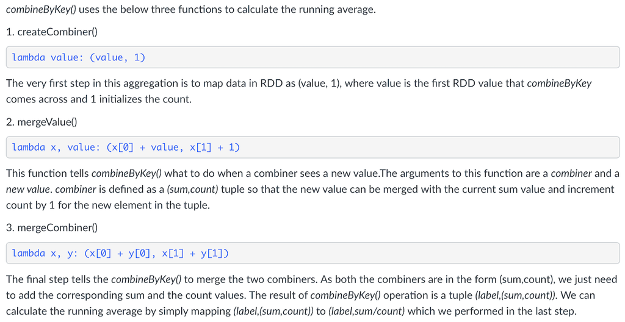

Aggregation with pair RDDs

```python
rdd = RDD.map(lambda row: (row['station'], row['Present_Tmin']))
```

```python
combiner_method = rdd.combineByKey(
                  lambda value: (value, 1), # create combiner
                  lambda x, value: (x[0] + value, x[1] + 1), # merge value
                  lambda x, y: (x[0] + y[0], x[1] + y[1])) # merge combiner
```

```python
# x[0]first element / x[1]second element to get the average
avg_ptmin = combiner_method.mapValues(lambda x: x[0] / x[1])
```

```python
results1 = avg_ptmin.collect()
```

```python
for result in results1:
    print(result)
```

```
('1', 21.16470589668922)
('2', 22.190322623714323)
('3', 23.441423922294938)
('4', 23.607443331128955)
('5', 23.04488445193854)
('6', 24.047868822441725)
('7', 23.773529395558477)
('8', 23.745245892884302)
('9', 23.11606556939297)
('10', 21.98967742612285)
('11', 23.644262245053152)
('12', 22.21147545361128)
('13', 23.898701314802295)
('14', 23.589215721180235)
('15', 23.36013071521435)
('16', 22.12759742489109)
('17', 21.749032278983822)
('18', 23.974193597609)
('19', 22.700326791775773)
('20', 23.058116912841797)
('21', 23.838110721849073)
('22', 23.820195418615683)
('23', 24.183870961589196)
('24', 24.281045764100316)
('25', 24.095806460226736)
(None, 20.59999990463257)
```

## 3.2 Joins

Messing around with data.

Lets create 2 new dataframes(subsets using the Present_Tmin and the Present_Tmax columns). Also, lets apply some of the transformation we did in section 3.

Join syntax -> join(self, other, on=None, how=None)

```python
df2 = df1.withColumn('Present_Tmin', col('Present_Tmin').cast('float'))
df3 = df1.withColumn('Present_Tmax', col('Present_Tmax').cast('float'))

new_df2 = df2.filter(~isnan(df2['Present_Tmin']))
new_df3 = df3.filter(~isnan(df3['Present_Tmax']))
```

### 3.3 Inner Join

Creating dummy dataframes df2 and df3. As a good practice, we will try to specify joins based on columns. We can perform joins like min.join(max) and it will inner join (PySpark default) Present_Tmin and Present_Tmax columns. Since we might be working with big data, we might want to specify the joins with columns or any other condition.

```python
min = new_df2.filter(new_df2['Present_Tmin'] < 25) # rows less than 25
max = new_df3.filter(new_df3['Present_Tmax'] > 26) # rows greater than 26
```

```python
# df = min.join(max) # inner join by default PySpark
```

Condition: Lets stick to 'station'. Following the syntax we join the two dataframes where 'station' column is equal for both. We state that we want an inner join for the following code.

```python
inner_df = max.join(min, max['station'] == min['station'], 'inner') # we are stating inner
inner_df.show()
```

```
+-------+----------+------------+------------+-----------+-----------+----------------+----------------+-----------+-----------+-----------+----------+-----------+-----------+----------+----------+----------+----------+-------+-------+-------+-----+---------------+---------+---------+-------+-------…
|station|      Date|Present_Tmax|Present_Tmin|LDAPS_RHmin|LDAPS_RHmax|LDAPS_Tmax_lapse|LDAPS_Tmin_lapse|   LDAPS_WS|   LDAPS_LH|  LDAPS_CC1| LDAPS_CC2|  LDAPS_CC3|  LDAPS_CC4|LDAPS_PPT1|LDAPS_PPT2|LDAPS_PPT3|LDAPS_PPT4|    lat|    lon|    DEM|Slope|Solar radiation|Next_Tmax|Next_Tmin|station|      D…
+-------+----------+------------+------------+-----------+-----------+----------------+----------------+-----------+-----------+-----------+----------+-----------+-----------+----------+----------+----------+----------+-------+-------+-------+-----+---------------+---------+---------+-------+-------…
|      1|2013-06-30|        28.7|        21.4|58.25568771|91.11636353|     28.07410146|     23.00693617|6.818886966|69.45180527|0.233947471|0.20389571|0.161696854|0.130928198|         0|         0|         0|         0|37.6046|126.991|212.335|2.785|    5992.895996|     29.1|     21.2|      1|2017-08…
|      1|2013-06-30|        28.7|        21.4|58.25568771|91.11636353|     28.07410146|     23.00693617|6.818886966|69.45180527|0.233947471|0.20389571|0.161696854|0.130928198|         0|         0|         0|         0|37.6046|126.991|212.335|2.785|    5992.895996|     29.1|     21.2|      1|2017-08…
|      1|2013-06-30|        28.7|        21.4|58.25568771|91.11636353|     28.07410146|     23.00693617|6.818886966|69.45180527|0.233947471|0.20389571|0.161696854|0.130928198|         0|         0|         0|         0|37.6046|126.991|212.335|2.785|    5992.895996|     29.1|     21.2|      1|2017-08…
|      1|2013-06-30|        28.7|        21.4|58.25568771|91.11636353|     28.07410146|     23.00693617|6.818886966|69.45180527|0.233947471|0.20389571|0.161696854|0.130928198|         0|         0|         0|         0|37.6046|126.991|212.335|2.785|    5992.895996|     29.1|     21.2|      1|2017-08…
|      1|2013-06-30|        28.7|        21.4|58.25568771|91.11636353|     28.07410146|     23.00693617|6.818886966|69.45180527|0.233947471|0.20389571|0.161696854|0.130928198|         0|         0|         0|         0|37.6046|126.991|212.335|2.785|    5992.895996|     29.1|     21.2|      1|2017-08…
|      1|2013-06-30|        28.7|        21.4|58.25568771|91.11636353|     28.07410146|     23.00693617|6.818886966|69.45180527|0.233947471|0.20389571|0.161696854|0.130928198|         0|         0|         0|         0|37.6046|126.991|212.335|2.785|    5992.895996|     29.1|     21.2|      1|2017-08…
|      1|2013-06-30|        28.7|        21.4|58.25568771|91.11636353|     28.07410146|     23.00693617|6.818886966|69.45180527|0.233947471|0.20389571|0.161696854|0.130928198|         0|         0|         0|         0|37.6046|126.991|212.335|2.785|    5992.895996|     29.1|     21.2|      1|2017-08…
|      1|2013-06-30|        28.7|        21.4|58.25568771|91.11636353|     28.07410146|     23.00693617|6.818886966|69.45180527|0.233947471|0.20389571|0.161696854|0.130928198|         0|         0|         0|         0|37.6046|126.991|212.335|2.785|    5992.895996|     29.1|     21.2|      1|2017-08…
|      1|2013-06-30|        28.7|        21.4|58.25568771|91.11636353|     28.07410146|     23.00693617|6.818886966|69.45180527|0.233947471|0.20389571|0.161696854|0.130928198|         0|         0|         0|         0|37.6046|126.991|212.335|2.785|    5992.895996|     29.1|     21.2|      1|2017-08…
|      1|2013-06-30|        28.7|        21.4|58.25568771|91.11636353|     28.07410146|     23.00693617|6.818886966|69.45180527|0.233947471|0.20389571|0.161696854|0.130928198|         0|         0|         0|         0|37.6046|126.991|212.335|2.785|    5992.895996|     29.1|     21.2|      1|2017-08…
|      1|2013-06-30|        28.7|        21.4|58.25568771|91.11636353|     28.07410146|     23.00693617|6.818886966|69.45180527|0.233947471|0.20389571|0.161696854|0.130928198|         0|         0|         0|         0|37.6046|126.991|212.335|2.785|    5992.895996|     29.1|     21.2|      1|2017-08…
|      1|2013-06-30|        28.7|        21.4|58.25568771|91.11636353|     28.07410146|     23.00693617|6.818886966|69.45180527|0.233947471|0.20389571|0.161696854|0.130928198|         0|         0|         0|         0|37.6046|126.991|212.335|2.785|    5992.895996|     29.1|     21.2|      1|2017-08…
|      1|2013-06-30|        28.7|        21.4|58.25568771|91.11636353|     28.07410146|     23.00693617|6.818886966|69.45180527|0.233947471|0.20389571|0.161696854|0.130928198|         0|         0|         0|         0|37.6046|126.991|212.335|2.785|    5992.895996|     29.1|     21.2|      1|2017-08…
```

[output cut: 9 more lines]

### 3.4 Cross Join

```python
xjoin_df = max.crossJoin(min) # We need to try an avoid this join when working with big data
xjoin_df.show()
```

```
+-------+----------+------------+------------+-----------+-----------+----------------+----------------+-----------+-----------+-----------+----------+-----------+-----------+----------+----------+----------+----------+-------+-------+-------+-----+---------------+---------+---------+-------+-------…
|station|      Date|Present_Tmax|Present_Tmin|LDAPS_RHmin|LDAPS_RHmax|LDAPS_Tmax_lapse|LDAPS_Tmin_lapse|   LDAPS_WS|   LDAPS_LH|  LDAPS_CC1| LDAPS_CC2|  LDAPS_CC3|  LDAPS_CC4|LDAPS_PPT1|LDAPS_PPT2|LDAPS_PPT3|LDAPS_PPT4|    lat|    lon|    DEM|Slope|Solar radiation|Next_Tmax|Next_Tmin|station|      D…
+-------+----------+------------+------------+-----------+-----------+----------------+----------------+-----------+-----------+-----------+----------+-----------+-----------+----------+----------+----------+----------+-------+-------+-------+-----+---------------+---------+---------+-------+-------…
|      1|2013-06-30|        28.7|        21.4|58.25568771|91.11636353|     28.07410146|     23.00693617|6.818886966|69.45180527|0.233947471|0.20389571|0.161696854|0.130928198|         0|         0|         0|         0|37.6046|126.991|212.335|2.785|    5992.895996|     29.1|     21.2|      1|2013-06…
|      1|2013-06-30|        28.7|        21.4|58.25568771|91.11636353|     28.07410146|     23.00693617|6.818886966|69.45180527|0.233947471|0.20389571|0.161696854|0.130928198|         0|         0|         0|         0|37.6046|126.991|212.335|2.785|    5992.895996|     29.1|     21.2|      2|2013-06…
|      1|2013-06-30|        28.7|        21.4|58.25568771|91.11636353|     28.07410146|     23.00693617|6.818886966|69.45180527|0.233947471|0.20389571|0.161696854|0.130928198|         0|         0|         0|         0|37.6046|126.991|212.335|2.785|    5992.895996|     29.1|     21.2|      3|2013-06…
|      1|2013-06-30|        28.7|        21.4|58.25568771|91.11636353|     28.07410146|     23.00693617|6.818886966|69.45180527|0.233947471|0.20389571|0.161696854|0.130928198|         0|         0|         0|         0|37.6046|126.991|212.335|2.785|    5992.895996|     29.1|     21.2|      4|2013-06…
|      1|2013-06-30|        28.7|        21.4|58.25568771|91.11636353|     28.07410146|     23.00693617|6.818886966|69.45180527|0.233947471|0.20389571|0.161696854|0.130928198|         0|         0|         0|         0|37.6046|126.991|212.335|2.785|    5992.895996|     29.1|     21.2|      5|2013-06…
|      1|2013-06-30|        28.7|        21.4|58.25568771|91.11636353|     28.07410146|     23.00693617|6.818886966|69.45180527|0.233947471|0.20389571|0.161696854|0.130928198|         0|         0|         0|         0|37.6046|126.991|212.335|2.785|    5992.895996|     29.1|     21.2|      6|2013-06…
|      1|2013-06-30|        28.7|        21.4|58.25568771|91.11636353|     28.07410146|     23.00693617|6.818886966|69.45180527|0.233947471|0.20389571|0.161696854|0.130928198|         0|         0|         0|         0|37.6046|126.991|212.335|2.785|    5992.895996|     29.1|     21.2|      7|2013-06…
|      1|2013-06-30|        28.7|        21.4|58.25568771|91.11636353|     28.07410146|     23.00693617|6.818886966|69.45180527|0.233947471|0.20389571|0.161696854|0.130928198|         0|         0|         0|         0|37.6046|126.991|212.335|2.785|    5992.895996|     29.1|     21.2|      8|2013-06…
|      1|2013-06-30|        28.7|        21.4|58.25568771|91.11636353|     28.07410146|     23.00693617|6.818886966|69.45180527|0.233947471|0.20389571|0.161696854|0.130928198|         0|         0|         0|         0|37.6046|126.991|212.335|2.785|    5992.895996|     29.1|     21.2|      9|2013-06…
|      1|2013-06-30|        28.7|        21.4|58.25568771|91.11636353|     28.07410146|     23.00693617|6.818886966|69.45180527|0.233947471|0.20389571|0.161696854|0.130928198|         0|         0|         0|         0|37.6046|126.991|212.335|2.785|    5992.895996|     29.1|     21.2|     10|2013-06…
|      1|2013-06-30|        28.7|        21.4|58.25568771|91.11636353|     28.07410146|     23.00693617|6.818886966|69.45180527|0.233947471|0.20389571|0.161696854|0.130928198|         0|         0|         0|         0|37.6046|126.991|212.335|2.785|    5992.895996|     29.1|     21.2|     11|2013-06…
|      1|2013-06-30|        28.7|        21.4|58.25568771|91.11636353|     28.07410146|     23.00693617|6.818886966|69.45180527|0.233947471|0.20389571|0.161696854|0.130928198|         0|         0|         0|         0|37.6046|126.991|212.335|2.785|    5992.895996|     29.1|     21.2|     12|2013-06…
|      1|2013-06-30|        28.7|        21.4|58.25568771|91.11636353|     28.07410146|     23.00693617|6.818886966|69.45180527|0.233947471|0.20389571|0.161696854|0.130928198|         0|         0|         0|         0|37.6046|126.991|212.335|2.785|    5992.895996|     29.1|     21.2|     13|2013-06…
```

[output cut: 9 more lines]

### 3.5 Left Join

```python
left_df = max.join(min, max['station'] == min['station'], 'left') # we are stating left
left_df.show()
```

```
+-------+----------+------------+------------+-----------+-----------+----------------+----------------+-----------+-----------+-----------+----------+-----------+-----------+----------+----------+----------+----------+-------+-------+-------+-----+---------------+---------+---------+-------+-------…
|station|      Date|Present_Tmax|Present_Tmin|LDAPS_RHmin|LDAPS_RHmax|LDAPS_Tmax_lapse|LDAPS_Tmin_lapse|   LDAPS_WS|   LDAPS_LH|  LDAPS_CC1| LDAPS_CC2|  LDAPS_CC3|  LDAPS_CC4|LDAPS_PPT1|LDAPS_PPT2|LDAPS_PPT3|LDAPS_PPT4|    lat|    lon|    DEM|Slope|Solar radiation|Next_Tmax|Next_Tmin|station|      D…
+-------+----------+------------+------------+-----------+-----------+----------------+----------------+-----------+-----------+-----------+----------+-----------+-----------+----------+----------+----------+----------+-------+-------+-------+-----+---------------+---------+---------+-------+-------…
|      1|2013-06-30|        28.7|        21.4|58.25568771|91.11636353|     28.07410146|     23.00693617|6.818886966|69.45180527|0.233947471|0.20389571|0.161696854|0.130928198|         0|         0|         0|         0|37.6046|126.991|212.335|2.785|    5992.895996|     29.1|     21.2|      1|2017-08…
|      1|2013-06-30|        28.7|        21.4|58.25568771|91.11636353|     28.07410146|     23.00693617|6.818886966|69.45180527|0.233947471|0.20389571|0.161696854|0.130928198|         0|         0|         0|         0|37.6046|126.991|212.335|2.785|    5992.895996|     29.1|     21.2|      1|2017-08…
|      1|2013-06-30|        28.7|        21.4|58.25568771|91.11636353|     28.07410146|     23.00693617|6.818886966|69.45180527|0.233947471|0.20389571|0.161696854|0.130928198|         0|         0|         0|         0|37.6046|126.991|212.335|2.785|    5992.895996|     29.1|     21.2|      1|2017-08…
|      1|2013-06-30|        28.7|        21.4|58.25568771|91.11636353|     28.07410146|     23.00693617|6.818886966|69.45180527|0.233947471|0.20389571|0.161696854|0.130928198|         0|         0|         0|         0|37.6046|126.991|212.335|2.785|    5992.895996|     29.1|     21.2|      1|2017-08…
|      1|2013-06-30|        28.7|        21.4|58.25568771|91.11636353|     28.07410146|     23.00693617|6.818886966|69.45180527|0.233947471|0.20389571|0.161696854|0.130928198|         0|         0|         0|         0|37.6046|126.991|212.335|2.785|    5992.895996|     29.1|     21.2|      1|2017-08…
|      1|2013-06-30|        28.7|        21.4|58.25568771|91.11636353|     28.07410146|     23.00693617|6.818886966|69.45180527|0.233947471|0.20389571|0.161696854|0.130928198|         0|         0|         0|         0|37.6046|126.991|212.335|2.785|    5992.895996|     29.1|     21.2|      1|2017-08…
|      1|2013-06-30|        28.7|        21.4|58.25568771|91.11636353|     28.07410146|     23.00693617|6.818886966|69.45180527|0.233947471|0.20389571|0.161696854|0.130928198|         0|         0|         0|         0|37.6046|126.991|212.335|2.785|    5992.895996|     29.1|     21.2|      1|2017-08…
|      1|2013-06-30|        28.7|        21.4|58.25568771|91.11636353|     28.07410146|     23.00693617|6.818886966|69.45180527|0.233947471|0.20389571|0.161696854|0.130928198|         0|         0|         0|         0|37.6046|126.991|212.335|2.785|    5992.895996|     29.1|     21.2|      1|2017-08…
|      1|2013-06-30|        28.7|        21.4|58.25568771|91.11636353|     28.07410146|     23.00693617|6.818886966|69.45180527|0.233947471|0.20389571|0.161696854|0.130928198|         0|         0|         0|         0|37.6046|126.991|212.335|2.785|    5992.895996|     29.1|     21.2|      1|2017-08…
|      1|2013-06-30|        28.7|        21.4|58.25568771|91.11636353|     28.07410146|     23.00693617|6.818886966|69.45180527|0.233947471|0.20389571|0.161696854|0.130928198|         0|         0|         0|         0|37.6046|126.991|212.335|2.785|    5992.895996|     29.1|     21.2|      1|2017-08…
|      1|2013-06-30|        28.7|        21.4|58.25568771|91.11636353|     28.07410146|     23.00693617|6.818886966|69.45180527|0.233947471|0.20389571|0.161696854|0.130928198|         0|         0|         0|         0|37.6046|126.991|212.335|2.785|    5992.895996|     29.1|     21.2|      1|2017-08…
|      1|2013-06-30|        28.7|        21.4|58.25568771|91.11636353|     28.07410146|     23.00693617|6.818886966|69.45180527|0.233947471|0.20389571|0.161696854|0.130928198|         0|         0|         0|         0|37.6046|126.991|212.335|2.785|    5992.895996|     29.1|     21.2|      1|2017-08…
|      1|2013-06-30|        28.7|        21.4|58.25568771|91.11636353|     28.07410146|     23.00693617|6.818886966|69.45180527|0.233947471|0.20389571|0.161696854|0.130928198|         0|         0|         0|         0|37.6046|126.991|212.335|2.785|    5992.895996|     29.1|     21.2|      1|2017-08…
```

[output cut: 9 more lines]

### 3.6 Right Join

```python
right_df = max.join(min, max['station'] == min['station'], 'right') # we are stating right
right_df.show()
```

```
+-------+----------+------------+------------+-----------+-----------+----------------+----------------+-----------+-----------+-----------+-----------+-----------+-----------+-----------+-----------+-----------+-----------+-------+-------+-------+-----+---------------+---------+---------+-------+--…
|station|      Date|Present_Tmax|Present_Tmin|LDAPS_RHmin|LDAPS_RHmax|LDAPS_Tmax_lapse|LDAPS_Tmin_lapse|   LDAPS_WS|   LDAPS_LH|  LDAPS_CC1|  LDAPS_CC2|  LDAPS_CC3|  LDAPS_CC4| LDAPS_PPT1| LDAPS_PPT2| LDAPS_PPT3| LDAPS_PPT4|    lat|    lon|    DEM|Slope|Solar radiation|Next_Tmax|Next_Tmin|station|  …
+-------+----------+------------+------------+-----------+-----------+----------------+----------------+-----------+-----------+-----------+-----------+-----------+-----------+-----------+-----------+-----------+-----------+-------+-------+-------+-----+---------------+---------+---------+-------+--…
|      1|2017-08-25|        27.8|          20|40.95186234|80.23045349|     26.63964097|     19.37032614|8.100240678|138.1438805|          0|          0|0.068010513|0.050291334|          0|          0|          0|          0|37.6046|126.991|212.335|2.785|    4806.717773|     25.8|     17.8|      1|20…
|      1|2017-08-23|        27.2|        22.7|87.06373596|97.43818665|     26.67744684|     22.49150134| 14.3917218|39.56188937|0.833612815|0.723819471|0.782037017|0.147638226|8.049212774|          0|1.151110443|          0|37.6046|126.991|212.335|2.785|    4879.562012|     25.5|     21.8|      1|20…
|      1|2017-08-22|        28.8|        21.1|79.37181091|97.26351929|     27.13002722|     23.14682187|9.019764741|31.62420529|0.340430492|0.728317263|0.778360143|0.622340204|          0|0.311344381|          0| 0.09154736|37.6046|126.991|212.335|2.785|    4915.481445|     27.4|     22.2|      1|20…
|      1|2017-08-18|        26.3|        21.4| 60.7138443|93.15583038|      28.2364765|     21.71139629|7.619222343|99.18272662|0.302727717|0.246376482|0.408781527|0.455212439|          0|          0|0.579740667|0.028136215|37.6046|126.991|212.335|2.785|    5053.921387|       26|     20.8|      1|20…
|      1|2017-08-12|        28.2|        21.1|62.50899124|88.93598175|     26.79040498|       21.760352|8.782101313|88.39788906|0.029019753| 0.32015688|0.519346896|0.703042249|          0|          0|          0|          0|37.6046|126.991|212.335|2.785|    5245.199219|     25.2|     21.3|      1|20…
|      1|2017-08-11|        29.2|        21.5|59.24028015|85.28312683|     29.91538275|     22.13205443|7.295952598| 111.038305|0.306907301| 0.08745181|0.480662905|0.271983078|          0|          0|          0|          0|37.6046|126.991|212.335|2.785|    5275.070313|     29.6|       21|      1|20…
|      1|2017-08-09|        28.3|        22.6|73.66584015|88.67181396|     26.69661119|     24.19035539|6.492666304|58.17036978| 0.40803666|0.444254705|0.482120956|0.429081632|          0|          0|          0|          0|37.6046|126.991|212.335|2.785|    5332.533691|     23.5|     21.6|      1|20…
|      1|2017-08-08|        27.9|        22.6| 54.1163826| 83.7817688|     30.72853203|     23.28411956|8.445366353|114.5605102|0.231280838|0.164754839|0.210047627|0.410844231|          0|          0|          0|          0|37.6046|126.991|212.335|2.785|    5360.637207|     28.6|     21.9|      1|20…
|      1|2017-08-07|        30.8|        23.9|74.20458984| 91.7940979|     27.35353749|     24.04660044|4.718111753|53.31374537|0.226570236|0.332631018| 0.59727007|0.458904171|          0|          0|          0|          0|37.6046|126.991|212.335|2.785|    5388.140137|     28.8|     22.5|      1|20…
|      1|2017-08-06|        29.3|        24.8|57.86719131| 92.5300827|     31.76156835|     24.32478293|6.784948071| 111.550152|0.047721784|0.049974883|0.022361247| 0.11706278|          0|          0|          0|          0|37.6046|126.991|212.335|2.785|    5415.057617|     31.1|     23.1|      1|20…
|      1|2017-08-05|        32.6|        25.4|66.68398285|90.56436157|     32.19945017|     26.62547248|7.104041557|91.36704731|0.431674299|0.511432122|0.190684434|0.156011943|          0|          0|          0|0.000217606|37.6046|126.991|212.335|2.785|    5441.393066|     30.1|     24.6|      1|20…
|      1|2017-08-04|        30.7|          23|48.80298233|86.82920837|      33.2502817|     25.50216644|6.949457506|  136.15039|0.012881946|0.021654709|0.010002368| 0.07126863|          0|          0|          0|          0|37.6046|126.991|212.335|2.785|    5467.114258|     33.4|     25.3|      1|20…
|      1|2017-08-03|        30.6|        24.5|50.50143433|85.78284454|     31.88095074|     23.61911044|7.328032196|126.1167825|0.046122793|0.319471503|0.187068632|0.078976874|          0|          0|          0|          0|37.6046|126.991|212.335|2.785|    5492.255371|     31.7|     22.8|      1|20…
```

[output cut: 9 more lines]

### 3.7 Semi Join (Left-Semi-Join)

```python
# only returns from the left side that has a match on the right side based
# on the condition provided for the join statement
semi_df = max.join(min, max['station'] == min['station'], 'leftsemi') # we are stating leftsemi
semi_df.show()
```

```
+-------+----------+------------+------------+-----------+-----------+----------------+----------------+-----------+-----------+-----------+-----------+-----------+-----------+----------+----------+----------+----------+-------+-------+-------+------+---------------+---------+---------+
|station|      Date|Present_Tmax|Present_Tmin|LDAPS_RHmin|LDAPS_RHmax|LDAPS_Tmax_lapse|LDAPS_Tmin_lapse|   LDAPS_WS|   LDAPS_LH|  LDAPS_CC1|  LDAPS_CC2|  LDAPS_CC3|  LDAPS_CC4|LDAPS_PPT1|LDAPS_PPT2|LDAPS_PPT3|LDAPS_PPT4|    lat|    lon|    DEM| Slope|Solar radiation|Next_Tmax|Next_Tmin|
+-------+----------+------------+------------+-----------+-----------+----------------+----------------+-----------+-----------+-----------+-----------+-----------+-----------+----------+----------+----------+----------+-------+-------+-------+------+---------------+---------+---------+
|      1|2013-06-30|        28.7|        21.4|58.25568771|91.11636353|     28.07410146|     23.00693617|6.818886966|69.45180527|0.233947471| 0.20389571|0.161696854|0.130928198|         0|         0|         0|         0|37.6046|126.991|212.335| 2.785|    5992.895996|     29.1|     21.2|
|      2|2013-06-30|        31.9|        21.6|52.26339722|90.60472107|     29.85068856|     24.03500932|5.691889932|51.93744783|0.225508198|0.251771373|0.159444059|0.127727264|         0|         0|         0|         0|37.6046|127.032|44.7624|0.5141|      5869.3125|     30.5|     22.5|
|      3|2013-06-30|        31.6|        23.3|48.69047928|83.97358704|     30.09129171|     24.56563342|6.138223678|20.57304966|0.209343664|0.257469446|0.204091465| 0.14212525|         0|         0|         0|         0|37.5776|127.058|33.3068|0.2661|    5863.555664|     31.1|     23.9|
|      4|2013-06-30|        32.0|        23.4|58.23978806|96.48368835|      29.7046289|     23.32617729|5.650050263|65.72714393|0.216372027|0.226002422| 0.16115741|0.134248676|         0|         0|         0|         0| 37.645|127.022| 45.716|2.5348|    5856.964844|     31.7|     24.3|
|      5|2013-06-30|        31.4|        21.9|56.17409515|90.15512848|     29.11393432|     23.48647993|5.735004306|107.9655353|0.151406899|0.249995278|0.178892475|0.170020995|         0|         0|         0|         0|37.5507|127.135| 35.038|0.5055|    5859.552246|     31.2|     22.5|
|      6|2013-06-30|        31.9|        23.5|52.43712616|85.30725098|     29.21934227|      23.8226129|6.182295263|50.23138913|0.185278777|0.280817986|0.232840977|0.146362898|         0|         0|         0|         0|37.5102|127.042|54.6384|0.1457|    5873.780762|     31.5|       24|
|      7|2013-06-30|        31.4|        24.4|56.28718948|81.01976013|     28.55185865|     24.23846712|5.587134739| 125.110007|0.389600243|0.333569981|0.270418989|0.145705371|         0|         0|         0|         0|37.5776|126.838|  12.37|0.0985|    5849.233398|     30.9|     23.4|
|      8|2013-06-30|        32.1|        23.6|52.32621765|78.00453949|     28.85198158|     23.81905389|6.104417304|42.01154665|0.357856423|0.344928144|0.272387332|0.143840614|         0|         0|         0|         0|37.4697| 126.91| 52.518|1.5629|    5863.992188|     31.1|     22.9|
|      9|2013-06-30|        31.4|          22|55.33879089|80.78460693|      28.4269752|     23.33237339|6.017135074|85.11097145|0.408765723|0.344800274| 0.26497959|0.148911073|         0|         0|         0|         0|37.4967|126.826|50.9312|0.4125|    5876.901367|     31.3|     21.6|
|     10|2013-06-30|        31.6|        20.5|56.65120316|86.84963226|     27.57670489|     22.52701832|6.518841068|63.00607544|0.348292483|0.306254824|0.245254185|0.135443459|         0|         0|         0|         0|37.4562|126.955|208.507|5.1782|    5893.608398|     30.5|       21|
|     11|2013-06-30|        31.7|        23.5|51.15639496|85.38563538|     29.69472429|     24.43264603|6.411812464|55.69031231|0.175333607|0.281865702|0.211470522|0.162906996|         0|         0|         0|         0|37.5372|127.085|   28.7|0.6233|    5864.000977|     31.2|     24.5|
|     12|2013-06-30|        31.6|        22.2|51.28834915| 80.3380127|     28.93631368|     24.36594852|6.423992604|28.71928795|0.251017448| 0.25629401|0.182101953|0.131399843|         0|         0|         0|         0|37.5507|126.988|132.118|0.5931|    5924.328613|     32.6|     22.2|
|     13|2013-06-30|        32.1|        23.8|48.76792908|84.00816345|     29.92927163|      24.2817497|5.988360584|32.03944751|0.183449507|0.271462449| 0.22561654|0.166153553|         0|         0|         0|         0|37.5776|127.083|59.8324|2.6865|    5861.027344|     31.4|     24.3|
```

[output cut: 9 more lines]

### 3.8 Anti Join (Left-anti-Join)

```python
# returns data that doesn't have a match on the right side table
# Only the columns on the left side table would be included in the result.
# Just the data filtered for the NOT IN condition
anti_df = max.join(min, max['station'] == min['station'], 'leftanti') # we are stating leftanti
anti_df.show()
```

```
+-------+----+------------+------------+-----------+-----------+----------------+----------------+-----------+-----------+-----------+----------+-----------+-----------+-----------+-----------+-----------+-----------+------+-------+-------+-------+---------------+---------+---------+
|station|Date|Present_Tmax|Present_Tmin|LDAPS_RHmin|LDAPS_RHmax|LDAPS_Tmax_lapse|LDAPS_Tmin_lapse|   LDAPS_WS|   LDAPS_LH|  LDAPS_CC1| LDAPS_CC2|  LDAPS_CC3|  LDAPS_CC4| LDAPS_PPT1| LDAPS_PPT2| LDAPS_PPT3| LDAPS_PPT4|   lat|    lon|    DEM|  Slope|Solar radiation|Next_Tmax|Next_Tmin|
+-------+----+------------+------------+-----------+-----------+----------------+----------------+-----------+-----------+-----------+----------+-----------+-----------+-----------+-----------+-----------+-----------+------+-------+-------+-------+---------------+---------+---------+
|   null|null|        37.6|        29.9| 98.5247345|100.0001526|     38.54225522|     29.61934244|21.85762099|213.4140062|0.967277328|0.96835306|0.983788755|0.974709524|23.70154408|21.62166078|15.84123484|16.65546921|37.645|127.135|212.335|5.17823|    5992.895996|     38.9|     29.8|
+-------+----+------------+------------+-----------+-----------+----------------+----------------+-----------+-----------+-----------+----------+-----------+-----------+-----------+-----------+-----------+-----------+------+-------+-------+-------+---------------+---------+---------+
```

# References:

`RDD vs Relational Database`:

- https://spark.apache.org/docs/latest/api/python/reference/api/pyspark.RDD.html
- https://www.tutorialspoint.com/pyspark/pyspark_rdd.htm
- https://www.oracle.com/database/what-is-a-relational-database/#:~:text=What%20is%20a%20Relational%20Database%20(RDBMS)%3F,of%20representing%20data%20in%20tables.
- https://intellipaat.com/blog/tutorial/spark-tutorial/programming-with-rdds/?US#:~:text=RDDs%20are%20the%20main%20logical,different%20machines%20of%20a%20cluster.
- https://www.analyticsvidhya.com/blog/2022/08/complete-guide-to-run-machine-learning-on-spark-using-spark-mllib/
- https://www.bmc.com/blogs/acid-atomic-consistent-isolated-durable/

`Word Account Application`

- https://www.learntospark.com/2020/01/word-count-program-in-apache-spark.html
- https://medium.com/@gulcanogundur/pyspark-word-count-b099106135a7
- https://www.geeksforgeeks.org/removing-stop-words-nltk-python/
- pronoun list: https://gist.github.com/mohataher/837a1ed91aab7ab6c8321a2bae18dc3e
- https://www.btb.termiumplus.gc.ca/tpv2guides/guides/wrtps/index-eng.html?lang=eng&lettr=indx_catlog_w&page=9mXNAo90UPlc.html
- https://www.geeksforgeeks.org/python-union-two-lists/
- https://www.w3schools.com/python/ref_set_union.asp
- https://sparkbyexamples.com/python/using-filter-with-lambda-in-python/
- https://www.geeksforgeeks.org/python-string-lower/

`Reductions in Spark`

- https://sparkbyexamples.com/pyspark/pyspark-convert-dataframe-to-rdd/
- https://sparkbyexamples.com/pyspark/pyspark-count-of-non-null-nan-values-in-dataframe/#:~:text=Solution%3A%20In%20order%20to%20find,isnan(df.name)%20.
- https://stackoverflow.com/questions/48632072/count-non-null-values-in-column-in-pyspark
- https://spark.apache.org/docs/3.1.1/api/python/reference/api/pyspark.sql.DataFrame.describe.html
- https://sparkbyexamples.com/pyspark/pyspark-cast-column-type/
- https://spark.apache.org/docs/latest/api/python/reference/pyspark.pandas/api/pyspark.pandas.isna.html
- https://spark.apache.org/docs/latest/api/python/reference/api/pyspark.RDD.combineByKey.html
- https://sparkbyexamples.com/pyspark/pyspark-join-explained-with-examples/
- https://sparkbyexamples.com/pyspark/pyspark-join-multiple-columns/
- https://www.geeksforgeeks.org/how-to-join-on-multiple-columns-in-pyspark/
- Join Types: https://medium.com/@achilleus/https-medium-com-joins-in-apache-spark-part-2-5b038bc7455b